# Visualizations LDA coefficients

```r
library(ggplot2)
library(dplyr)
library(tidyr)
library("ggpubr")
library(LDATS)
library(ggVennDiagram)
library(stringr)
library(abind)
library(patchwork)

source("utils.R")
```

Visualizations on three sets of networks. First set consists of networks trained in 30 replications on CIFAR 10 training set with 500 sample validation set extracted randomly in each replication. Second set consists of networks trained in a single replication on half of CIFAR 10 training set. Third set are networks trained in 10 replications on half of CIFAR 100 training set.

## CIFAR 10

```r
base_dir <- "../data/data_train_val_c10"
repls <- 0:29
classes <- 10
lda_coefs <- load_lda_coefs(base_dir, repls)
net_pw_results <- read.csv(file.path(base_dir, "net_pw_accuracies.csv"))
ens_pw_results <- read.csv(file.path(base_dir, "ensemble_pw_accuracies.csv"))
ens_pw_cal <- read.csv(file.path(base_dir, "ensemble_pw_calibration.csv"))
ens_pw_irrel <- read.csv(file.path(base_dir, "ensemble_pw_irrelevant.csv"))
net_pw_results[, c("class1", "class2")] <- lapply(net_pw_results[, c("class1", "class2")], as.factor)
ens_pw_results[, c("class1", "class2")] <- lapply(ens_pw_results[, c("class1", "class2")], as.factor)
ens_pw_cal$bin_c <- (ens_pw_cal$conf_min + ens_pw_cal$conf_max) / 2
ens_pw_cal[, c("class1", "class2", "bin_c")] <- lapply(ens_pw_cal[, c("class1", "class2", "bin_c")], as.factor)
ens_pw_irrel[, c("class1", "class2")] <- lapply(ens_pw_irrel[, c("class1", "class2")], as.factor)
```

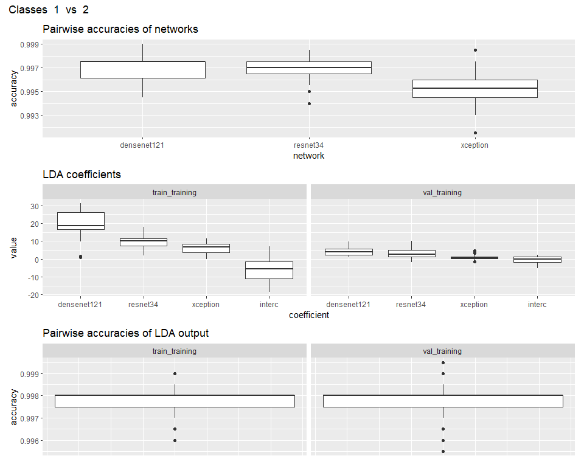

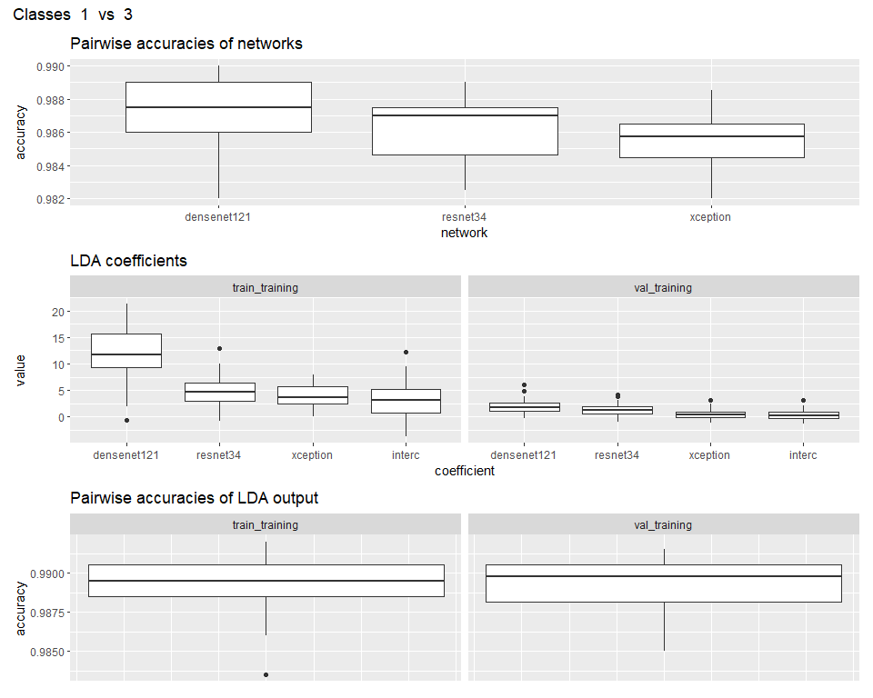

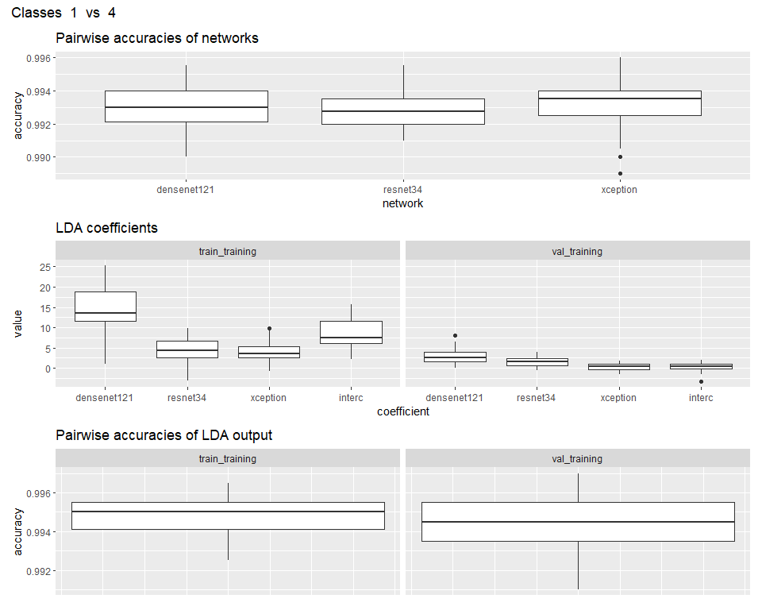

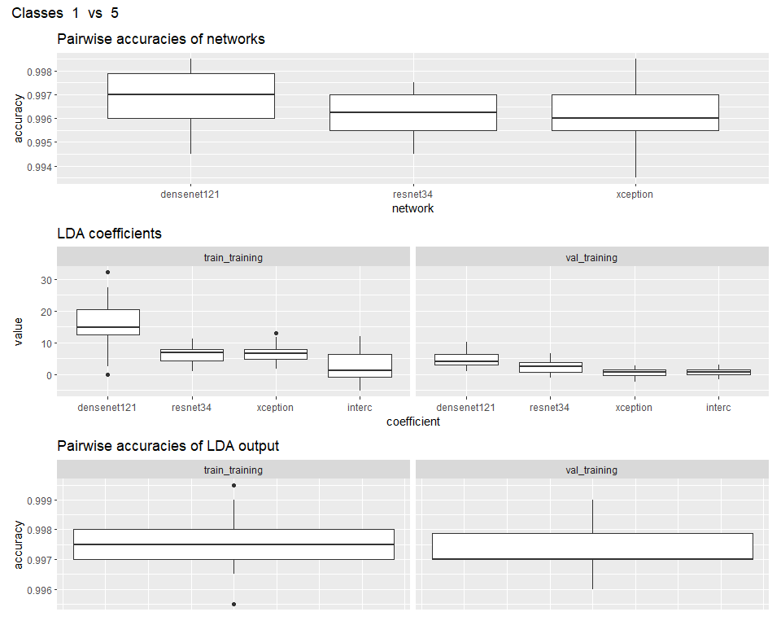

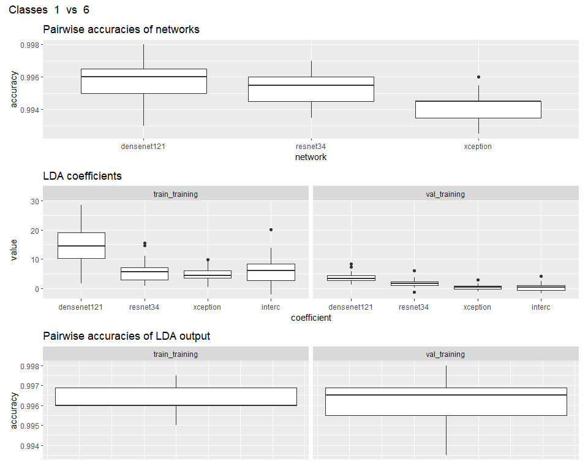

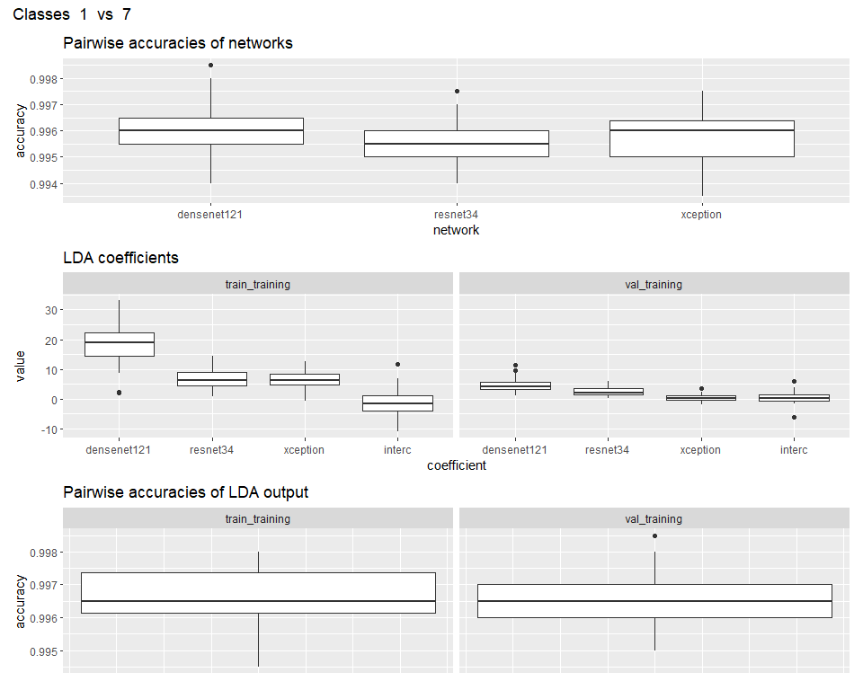

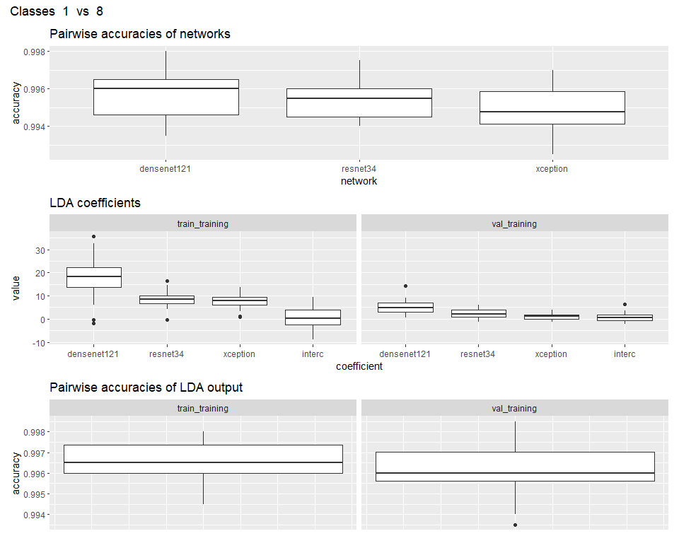

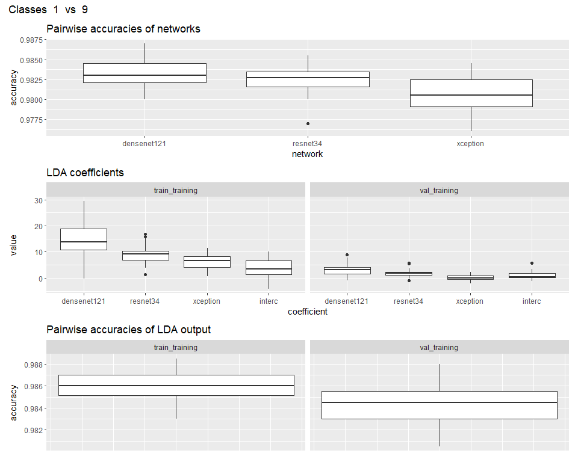

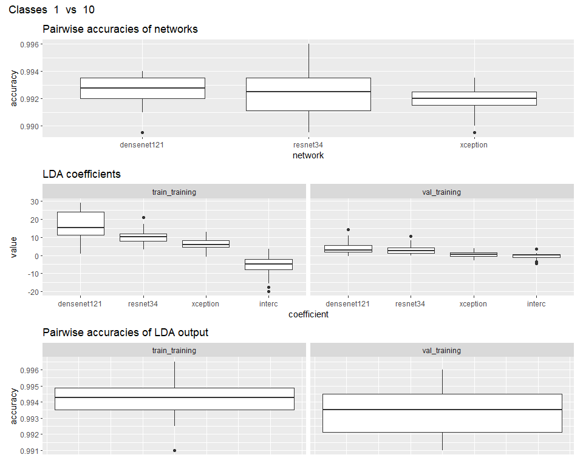

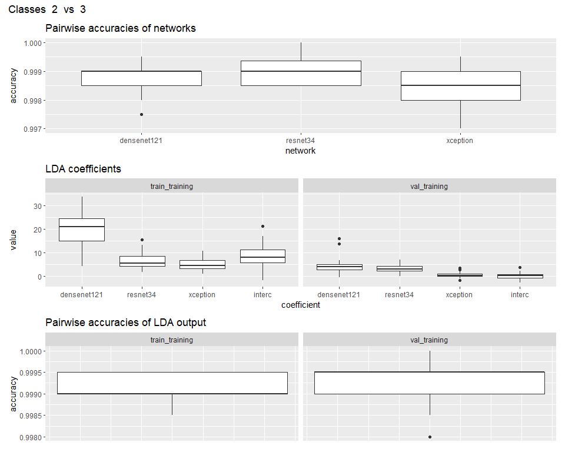

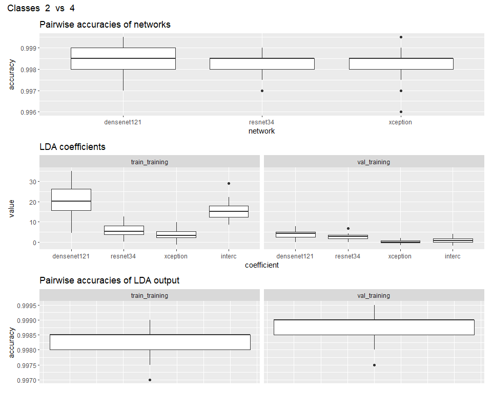

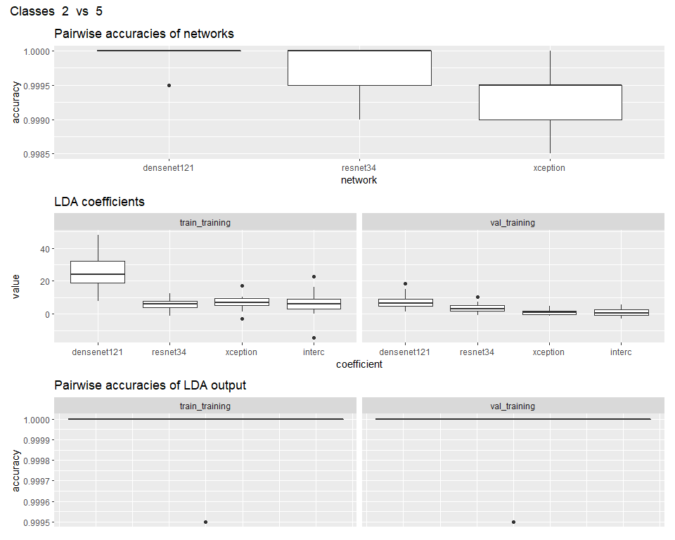

[33 more figures not shown]

```r
for (cl1 in 1:(classes - 1))
{
  for (cl2 in (cl1 + 1):classes)
  {
    lda_plt <- lda_coefs %>% filter(class1 == cl1 & class2 == cl2) %>% ggplot() + geom_boxplot(aes(x=coefficient, y=value)) +
      facet_wrap(~train_type) + ggtitle("LDA coefficients")

    acc_plt_net <- net_pw_results %>% filter(class1 == (cl1 - 1) & class2 == (cl2 - 1)) %>% ggplot(mapping=aes(x=network, y=accuracy)) +
      geom_boxplot() + ggtitle("Pairwise accuracies of networks")

    acc_plt_ens <- ens_pw_results %>% filter(class1 == (cl1 - 1) & class2 == (cl2 - 1)) %>% ggplot(mapping=aes(y=accuracy)) +
      geom_boxplot() + facet_wrap(~train_set) + ggtitle("Pairwise accuracies of LDA output") +
      theme(axis.ticks.x=element_blank(), axis.text.x=element_blank())


    print((acc_plt_net/lda_plt/acc_plt_ens) + plot_annotation(title=paste("Classes ", cl1, " vs ", cl2)))
  }
}
```

An attempt to visualize calibration of LDAs. Almost all elements are present near the zero and one probabilities, therefore the visualization is not very informative.

[output not shown]

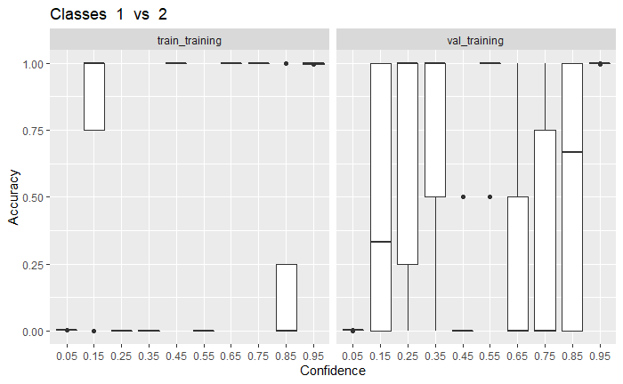

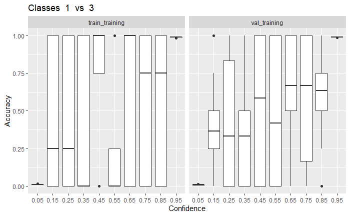

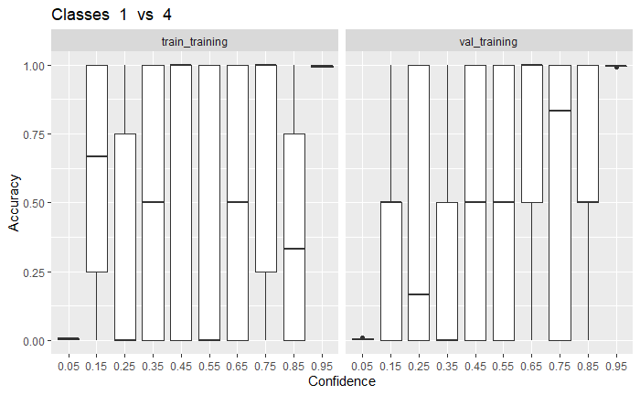

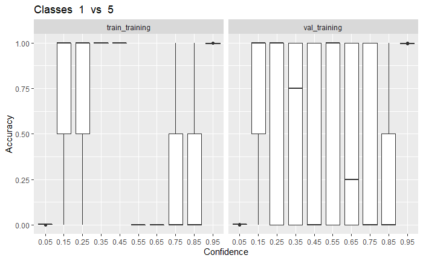

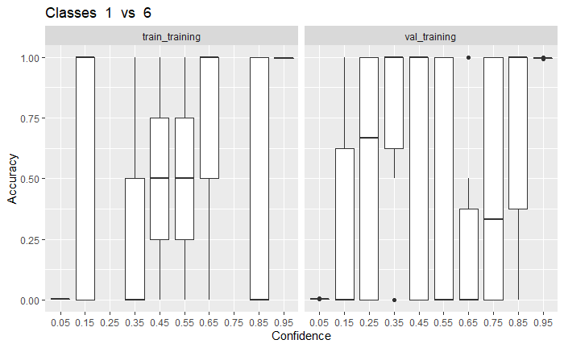

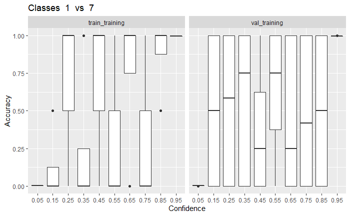

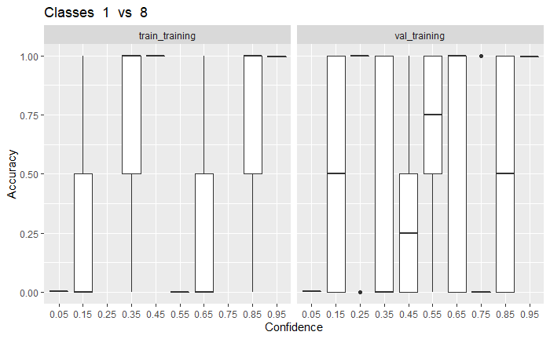

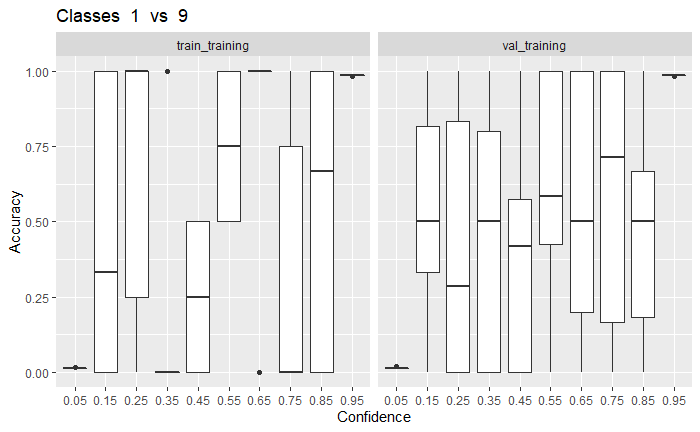

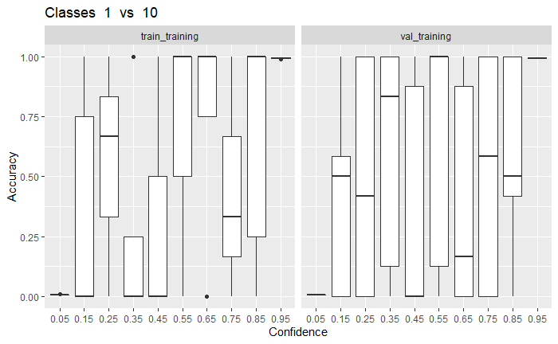

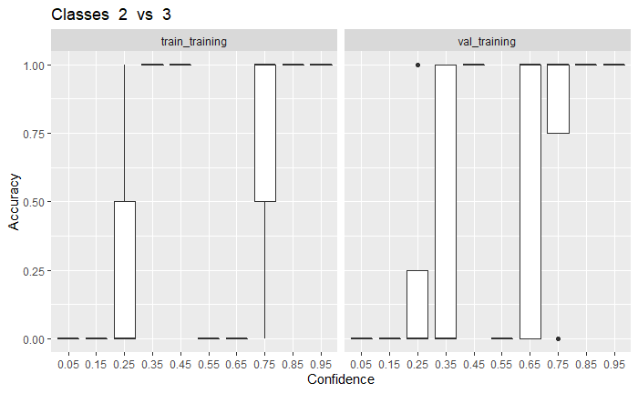

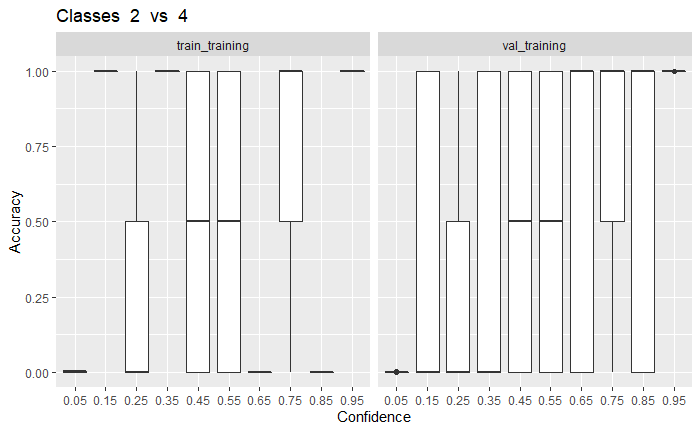

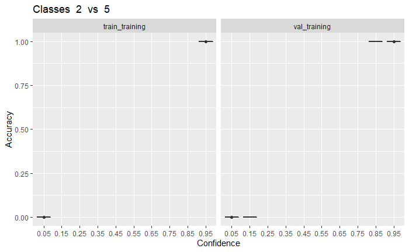

[33 more figures not shown]

```r
for (cl1 in 1:(classes - 1))
{
  for (cl2 in (cl1 + 1):classes)
  {
    cal_plt <- ens_pw_cal %>% filter(class1 == (cl1 - 1) & class2 == (cl2 - 1)) %>% ggplot() +
      geom_boxplot(mapping=aes(x=bin_c, y=bin_accuracy)) + facet_wrap(~train_set) +
      ggtitle(paste("Classes ", cl1, " vs ", cl2)) + xlab("Confidence") + ylab("Accuracy")

    print(cal_plt)
  }
}
```